# Edit Wars When Stars and Condoms Collide

Lilly, Joe, Adriana, Mike, Stephanie

April 10, 2018

# Introduction

## Original Data

- Complete edit history of all Wikipedia (2001-2008).
- Original zip file > 18 GB, unzipped raw data file > 291 GB.

[figure not shown]

## Our project

1. Edit Wars?
2. How we found them
3. A closer look into the articles for *Barnard’s Star* and *Condoms*

# What are edit wars and how to find them?

## Process Flow

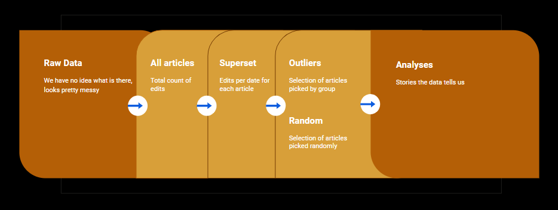

## Raw Data - Munging

```r
cat(raw.txt)
```

```
## REVISION 12 122974 Anarchism 2002-07-23T01:12:22Z Brion_VIBBER 51
## CATEGORY IMAGE MAIN Syndicalism Nihilism Gustave_de_Molinari Benjamin_Tucker
## Benjamin_Tucker Noam_Chomsky Peter_Kropotkin Leo_Tolstoy Leo_Tolstoy
## Classical_liberalism Individualist_anarchism Individualist_anarchism
## Individualist_anarchism Individualist_anarchism Libertarianism Libertarianism
## Anomie Anomie Mutual_aid Mutual_aid General_strike Atheism Free_Spirit
## Libertarian_socialism Libertarian_socialism Libertarian_socialism
## Lysander_Spooner Capitalism Mikhail_Bakunin Self-defense Political Minarchism
## Punk_rock William_McKinley Anarcho-syndicalists Karl_Marx Anarchism/Todo
## Coercion John_Locke Anarcho-capitalism Anarcho-capitalism Anarcho-capitalism
## Anarcho-capitalism Regicide Government Michael_Bakunin Property_damage
## Max_Stirner Rudolph_Rocker Peter_Kroptkin Non-violent_resistance Proudhon
## David_Friedman Voltairine_de_Cleyre TALK USER USER_TALK OTHER Pl:Anarchizm
## Fr:Anarchisme Eo:Anarkismo EXTERNAL TEMPLATE COMMENT lang links: +fr, pl
## MINOR 1 TEXTDATA 1169
```

## First look at the structured data

```r
cat(output.txt)
```

```
## REVISION 12 18201 Anarchism 2002-02-25T15:00:22Z ip:Conversion_script
## p:Conversion_cript
## CATEGORY
## IMAGE
## MAIN Syndicalism Nihilism Gustave_de_Molinari Benjamin_Tucker Benjamin_Tucker
## inarchism Noam_Chomsky Punk_rock Fascism Anarchism/Todo Coercion John_Locke
## eo_Tolstoy Anarcho-capitalism Anarcho-capitalism Anarcho-capitalism
## TALK Anarchy Anarchism
## USER
## USER_TALK
## OTHER
## EXTERNAL http://dwardmac.pitzer.edu/anarchist_archives/kropotkin.html
## http://recollectionbooks.com/bleed/sinners/RockerRudolf.htm
## http://www.wikipedia.com/wiki.cgi?action=history&id=Anarchy
## TEMPLATE
## COMMENT Automated conversion
## MINOR 1
## TEXTDATA 1214
```

## What does 291 GBs of data give us?

- 2,953,385 Unique Articles
- 116,590,855 Edits

## All articles: *What does it look like?*

```r
pandoc.table(head(inital_output_example), justify = 'right')
```

```
##
## --------------------------------------
##                           Name   Count
## ------------------------------ -------
##                            !!!     302
##
##                 !!!Fuck_You!!!      88
##
##   !!!Fuck_You!!!_And_Then_Some       1
##
##   !!!Fuck_You!!!_and_Then_Some      81
##
##                    !!!_(album)      71
##
##                             !!      41
## --------------------------------------
```

## Superset: Making sense of the data!

Getting a list of articles edited by date:

```r
pandoc.table(head(top1000_revisions_in_a_day[,1:3], 6), justify = 'right')
```

```
##
## -------------------------------------------
##         Date                   Name   Count
## ------------ ---------------------- -------
##   12/29/2001         Deaths_in_2003      55
##
##   12/30/2001         Deaths_in_2003      54
##
##     6/2/2002            Han_Dynasty      75
##
##    10/2/2002              Anarchism      79
##
##   10/20/2002   Christopher_Columbus      47
##
##   10/24/2002     Politics_of_Canada      52
## -------------------------------------------
```

## Data Structure and fields we used

- `REVISION` ***
- `CATEGORY`
- `IMAGE`
- `MAIN`
- `EXTERNAL`
- `TEMPLATE`
- `COMMENT` ***
- `MINOR`
- `TEXTDATA`

## Datasets

- *Superset*
  - A list of every article’s date and number of edits for that date.
- *Outliers*
  - The mean number of edits per day for each article (top 5%).
- *Random*
  - Excluding the previous 67 articles, we radomly picked another 67 articles.

# Found something we can actually use! Now what?

## Number of comments and unique users

- Take a look at the data
- Assumptions
- Goals

## Top 10 Edits:

[interactive chart not shown]

## Top 10 Edit Wars

[interactive chart not shown]

## Goals

- Create a methodology
- Find something interesting
- Tell a story

We found several good stories to tell, we brought you two.

# Barnard’s Star

## What triggered the mass edits?

[Barnard’s Star](https://en.wikipedia.org/wiki/Barnard%27s_Star)

Barnard’s Star was the wikipedia “article of the day” when it saw its spike in edits. We attribute the spike in edits to be due to the people “trolling” this article due to its unexpected exposure as being selected as the article of the day on October 18, 2007.

https://en.wikipedia.org/wiki/Wikipedia:Today%27s_featured_article/October_18,_2007

## Wordcloud

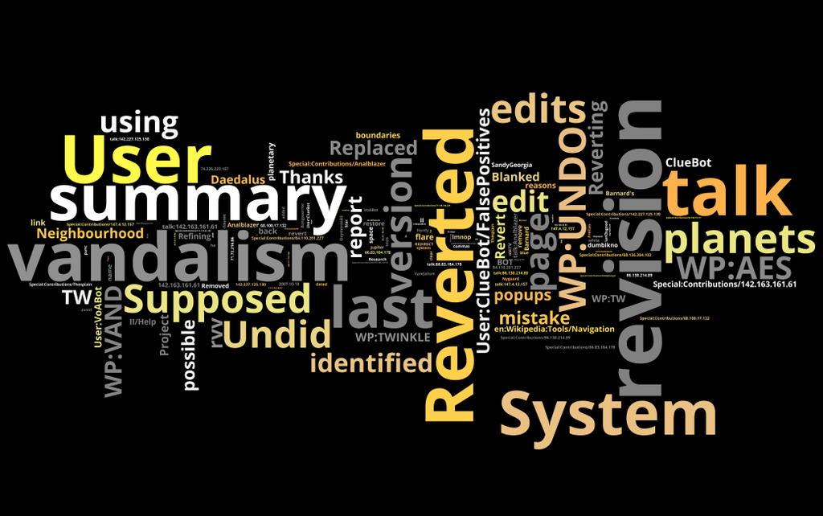

# Condom

## What triggered the mass edits?

Condom

On December 25, 2005, the Catholic Church released a statement stating that “Safe sex” in regards to sexual activity using condoms is not actually safe. The condom article saw its spike in edits on December 26, 2005 - one day after this released statement.

https://catholicnews.sg/index.php?option=com_content&view=article&id=709:e2809csafe-sexe2809d-is-not-really-safe&catid=140:december-2005&Itemid=473&lang=en

## Wordcloud

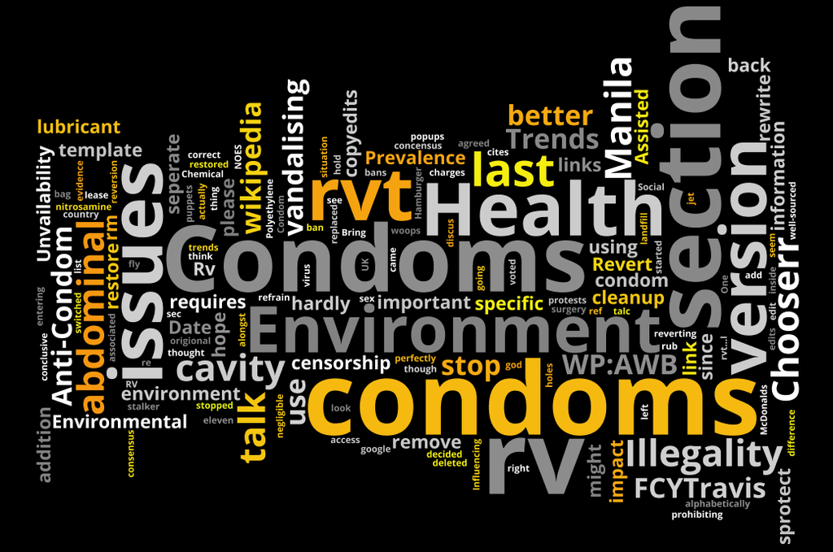

## Edit War Flags

Dataset: Outlier, Article: Condom, UniqueUser: 17, TotalRevisions: 94 Ratio: 0.1809